## Student UID: 113145995

# 1. Making objects, assigning values, and simple arithmetic

Make three objects named *x, y, and x*. Assign any numerical value to each & then multiply them together.

```r
x<-c(8)
y<-c(10)
z<-c(3)

v<-x*z*y
v
```

```
## [1] 240
```

# 2. Creating vectors

Create three vectors. Name the first *myVec* and have it contain any 5 numbers. Name the second *myRep* and have it contain the number 10 repeated 217 times. The third should be named *mySeq* and contain a sequence of numbers from 1-100, counting by 0.25. Have R return the length of *mySeq*.

```r
myVec<-c(1,2,3,4,5)
myRep<-rep(10, 217)
mySeq<-seq( from=1, to=100, by=0.25 )
length(unique(mySeq))
```

```
## [1] 397
```

# 3. Working with objects, files, directories

Execute functions to:

- list the objects in your workspace
- print your current working directory
- list the files and folders in your current working directory
- save your workspace

```r
ls()
```

```
## [1] "myRep" "mySeq" "myVec" "v"     "x"     "y"     "z"
```

```r
getwd()
```

```
## [1] "/Users/elsketielens/phd/coursework/MEES614/mees614-2015-tielens/mees614-2015-113145995/skillTest"
```

```r
#save.workspace()
```

# 4. Loading, saving, plotting, and indexing data

Load the iris dataset & do the following:

- Make a new object that has the value in row 10, column 1.
- Assign new values to the 5th row of the iris dataset by multiplying the current values by 2.
- Make a new object containing rows 1-10, 15, 35-40 and columns 1-2, 5 from the iris dataset.
- Make a new object that contains everything except the 10th row of the iris dataset.
- Make a new object that contains only those records with a sepal length greater than 5.
- Make a new object by subsetting the iris dataset so that it contains only the records for **setosa** and save this object to your hard drive as a csv.
- Plot *Sepal Length* vs. *Sepal Width* from the full iris dataset.

```r
##1
data(iris)
t<-iris[10,1]
str(iris)
```

```
## 'data.frame':    150 obs. of  5 variables:
##  $ Sepal.Length: num  5.1 4.9 4.7 4.6 5 5.4 4.6 5 4.4 4.9 ...
##  $ Sepal.Width : num  3.5 3 3.2 3.1 3.6 3.9 3.4 3.4 2.9 3.1 ...
##  $ Petal.Length: num  1.4 1.4 1.3 1.5 1.4 1.7 1.4 1.5 1.4 1.5 ...
##  $ Petal.Width : num  0.2 0.2 0.2 0.2 0.2 0.4 0.3 0.2 0.2 0.1 ...
##  $ Species     : Factor w/ 3 levels "setosa","versicolor",..: 1 1 1 1 1 1 1 1 1 1 ...
```

```r
#2?
s<-iris[5, ]
s2<-s*2
#cannot do this with species (=factor)
#3?
i1<-subset(iris[1:10,1:2])
i2<-subset(iris[15,1:2])
i3<-subset(iris[35:40:10,1:2])
```

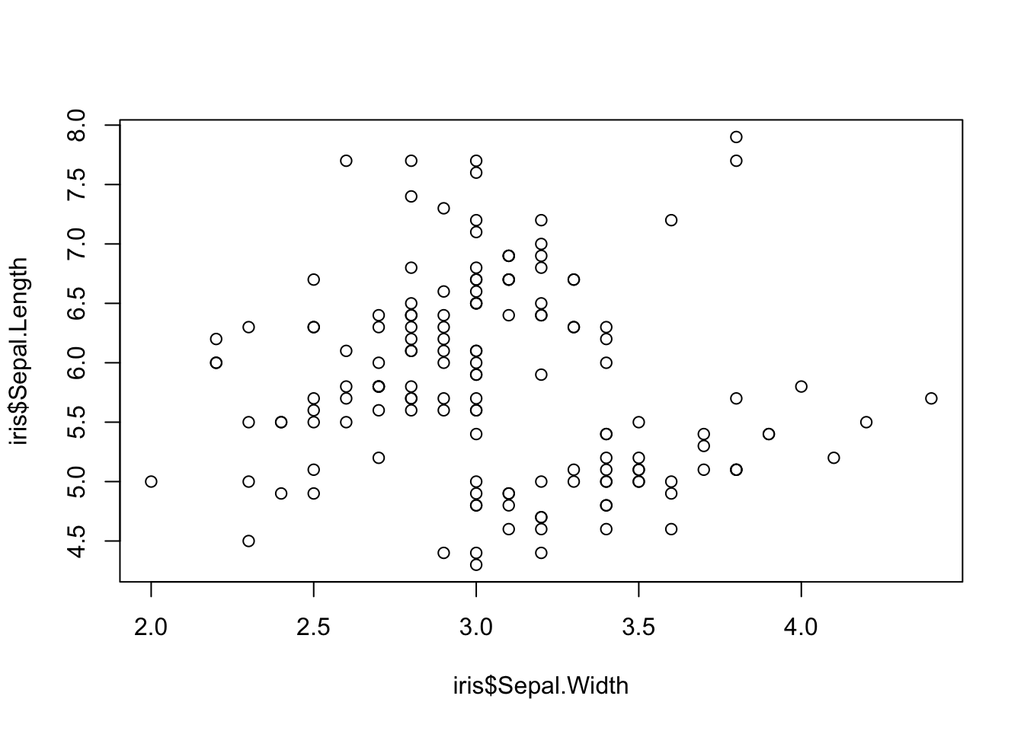

```r
#i4<-cbind(i1,i2,i3)

#4
iris2<-iris
iris2<-iris[-10, ]
#5
newobject2<-iris$Sepal.Length>5
b<-iris$Sepal.Length[ iris$Sepal.Length > 55 ]
#data<-cbind(iris$Sepal.Length, iris$Sepal.Width)

#6
iris3 <- subset(iris, iris$Species=="setosa")
#7
plot(iris$Sepal.Length~iris$Sepal.Width )
```

# 5. Lists and Dataframes

Create a list that contains *myVec*, *myRep*, and *mySeq*. Create a dataframe from the first five values of *myVec*, *myRep*, and *mySeq*. Have R return the dimensions and structure of the dataframe and, separately, the number of rows, columns, and column names. Save the dataframe as a csv table.

```r
#data.frame(cbind(myVec, myRep, mySeq)
```

# 6. Installing and Loading packages

Install and then load the *dismo* package.

```r
#library(dismo)
```

# 7. Plotting

A. Create a histogram of the sepal length data from the iris dataset and add to it:

- A density curve
- A normal curve
- A legend

B. Load and plot the lynx dataset, then create a new plot as follows:

*Make a combined point-line plot, using character code 21 for the points and a line width of 3 for the segments.* Make the line segments and outline of the points blue. Make the fill of the points grey. *Label the y-axis* Count* and the x-axis *Year* *Lastly, plot the new plot and the original side-by-side in the same window.

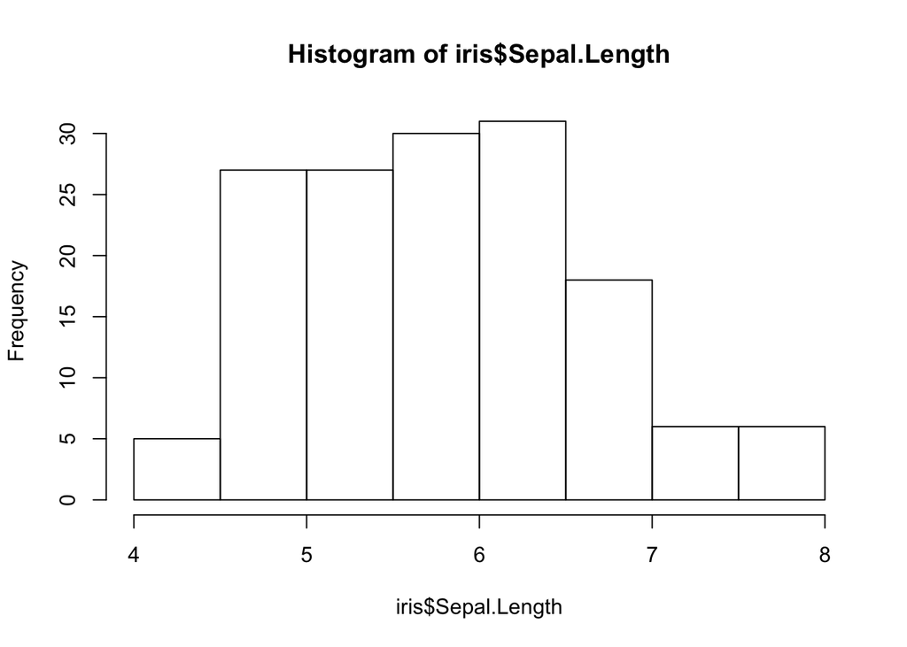

```r
hist(iris$Sepal.Length)
```

# 8. Writing for-loops

A. Write a for-loop the prints “1. Hello world!” five times, replacing the numer with the current interation of the for-loop.

B. Write a nested for-loop that assigns a random number drawn from a uniform distribution (see ?runif) between 0-1 to each position within a 25 x 25 matrix named *myMat*. Use the *image* function to plot a heatmap of your matrix. Create an object that has only the values in your matrix that are greater than 0.5.

```r
#M <- matrix( data=NA, nrow=5, ncol=1 )

#for(i in 5:1){M[ ,i]<- c("Hello world!")} M
```

# 9. Using *apply* functions

Use the apply function to calculate the row means of *myMat* from #8 above.

```r
#ddply(.data=myMat, .variables="8", .fun="mean"")
```

# 10. Writing custom functions

Write a simple function that will calculate the cube of any number. Plot the results for values 0-10.

```r
# simple function to return square of a number
```

# 11. If-else statements

Write an if-else statement to calculate the price of a speeding ticket, with the following rules:

1. The ticket fee is $25 for every mile per hour above 55.
2. Plus an additional $50 for every mile per hour above 65.
3. There is an additional $100 charge for red cars.

*What is the ticket fee for a red car traveling 75 mph?* What is the ticket fee for a black car traveling 58?

# 12. Finishing up

Save your workspace & then clear it.